# `StatARPLS`

An R Package for Baseline Correction of Spectra with Automatic Smoothing and Uncertainty

Taruna Dagur

## Mindmap

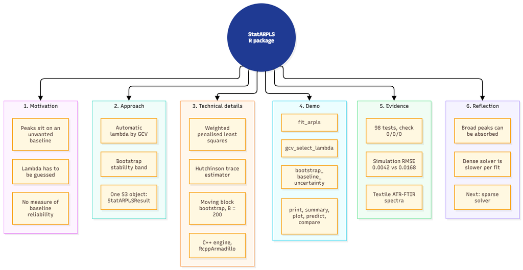

# 1 Problem and contribution

## 1.1 The research problem

Spectra (FTIR, Raman, UV-Vis) = **true peaks** on top of an unwanted, slowly varying **baseline**.

- Baseline correction is often needed before peak detection.
- The true baseline is **never observed**, so it has to be estimated.
- The popular statistical method, **ARPLS**, depends on user-chosen parameters:
  - $\lambda$ controls how flexible the baseline is.
  - A poor choice gives a baseline that cuts into peaks, or one that misses the background.
- Existing tools return **one baseline, with no sign of how trustworthy it is**.

## 1.2 Existing tools and their gaps

| Tool | What it offers | Gap in the comparison |
| --- | --- | --- |
| `baseline` (R) | Several baseline correction methods, including AsLS, IRLS and polynomial fitting. | In the methods compared, lambda is set manually. ARPLS and a bootstrap-based baseline stability band are not provided by these methods. |
| `hyperSpec` (R) | Tools for handling spectral data, with polynomial and rubberband baseline correction. | The methods compared do not provide the same ARPLS workflow with automatic lambda selection and a bootstrap-based stability band. |
| ARPLS-related papers | Published ARPLS-related methods and variants, such as airPLS and asPLS. | StatARPLS focuses on integrating baseline fitting, automatic lambda selection and bootstrap-based stability assessment into one documented R package. |

- Best $\lambda$ is **dataset-specific** and does not transfer [1].
- ARPLS can also **absorb broad peaks** into the baseline.

## 1.3 Core contribution: `StatARPLS`

**What it adds**

- **Automatic $\lambda$**: generalised cross-validation (GCV) with a fast trace estimate.
- **Baseline uncertainty**: moving-block residual bootstrap gives a stability band.
- **Compiled solver** (Rcpp / RcppArmadillo)
- One S3 object, `StatARPLSResult`, with `print`, `summary`, `plot`, `predict`, `compare`.

**What it does not claim**

- Not a new selection criterion: GCV and bootstrap are established tools.
- The contribution is a **tested, documented R implementation that integrates both**.

# 2 Method

## 2.1 Method: ARPLS in two equations

Weighted penalised least squares (Whittaker smoother), second-difference penalty:

$$\min_z \sum_i w_i (y_i - z_i)^2 +
\lambda \sum_i (\Delta^2 z_i)^2 \;\;\Rightarrow\;\; (W + \lambda D^\top
D)\,z = W\,y$$

Weights are **re-estimated each iteration** from the residuals $r_i = y_i - z_i$:

$$w_i = \frac{1}{1 +
\exp\!\left(2\,\dfrac{r_i - (2s - m)}{s}\right)}$$

where $m$ and $s$ are the mean and standard deviation of the **negative** residuals.

- Points far **above** the baseline (peaks) get weight near 0, so they stop pulling the fit up.
- Iterate until the weights stop changing. (A tiny ridge, $10^{-6}$, is added to the diagonal so the solve never fails.)
- The first equation draws a smooth curve through the data. $\lambda$ sets how stiff the curve is: large $\lambda$ gives a stiff, smooth curve; small $\lambda$ lets it bend.
- The second equation decides how much each point counts. A point well above the curve is probably a peak, so its weight drops towards 0 and it stops dragging the curve up.
- Fit, reweight, refit: repeat until the weights settle.

## 2.2 Method: what we add

**Choosing $\lambda$ by GCV** (weighted residuals, effective degrees of freedom $\mathrm{tr}\,H_\lambda$):

$$\mathrm{GCV}(\lambda) = \frac{n \sum_i
w_i r_i^2}{\left(n - \mathrm{tr}\,H_\lambda\right)^2}$$

where $H_\lambda = (W + \lambda D^\top D)^{-1} W$, and $\mathrm{tr}\,H_\lambda$ is estimated with **Hutchinson’s randomised trace estimator**:

$$\mathrm{tr}\,H_\lambda \approx
\frac{1}{m}\sum_{k=1}^{m} u_k^\top H_\lambda u_k, \quad u_k \text{
random } \pm 1 \text{ vectors},\; m = 30$$

**In plain words**: GCV rewards a curve that follows the data, but charges a penalty for flexibility ($\mathrm{tr}\,H_\lambda$ counts how flexible the curve is). The best $\lambda$ balances the two. Hutchinson’s trick estimates that flexibility count cheaply instead of computing it exactly.

**Uncertainty by moving-block bootstrap** (fixed $\lambda$):

1. Resample **blocks** of residuals at baseline points (keeps serial correlation).
2. Pseudo-signal $y^* = \hat z + e^*$, refit the baseline, repeat $B$ times.
3. Band = the fitted baseline shifted by the 2.5% and 97.5% quantiles of the refits (centred on the fit).

It makes many fake spectra that have the same baseline and the same kind of noise, refit each one, and see how much the baseline moves. A small spread means the baseline is stable against noise.

# 3 Package design

## 3.1 Package design: workflow

**Input**  
intensity vector  
+ wavenumber axis

→

`gcv_select_lambda()`  
validate axis,  
choose λ, fit

→

`bootstrap_baseline_uncertainty()`  
stability band

→

**StatARPLSResult**  
(S3 object)

→

`print` `summary`  
`plot` `predict`  
`compare`

- `fit_arpls()` is the single-$\lambda$ fit; the other two share its compiled engine. No circular dependencies between modules.

## 3.2 Key design choices

- **S3 classes**: simple, idiomatic, easy for users to extend.
- **Rcpp + RcppArmadillo**: the ARPLS solve is the hot loop; a pure-R reference engine is kept to verify it.
- **Base graphics only**: no ggplot2, so no extra dependency footprint.
- **Input checks up front**: finite values, strictly increasing wavenumbers (clear error telling the user to sort), a warning for uneven spacing.
- **Reproducible**: `seed` arguments restore the caller’s random-number state on exit.
- **Honest limits built in**: a warning when GCV picks the smallest $\lambda$ in the grid.

## 3.3 Runtime view: data flow

*What happens when it runs?*

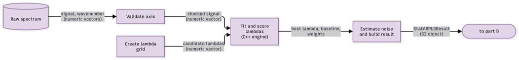

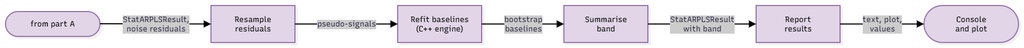

- Part A selects $\lambda$ by GCV and fits the baseline; part B resamples the noise residuals and refits to get the stability band.
- Fixed-$\lambda$ users skip the grid: `fit_arpls()` goes from validation straight to the fit.

## 3.4 Module view: package diagram

*How is the code organised?*

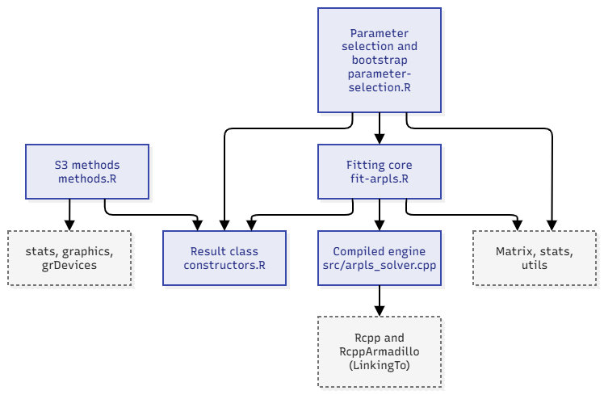

- Dependencies point one way only: methods and selection depend on the result class; selection depends on the fitting core; the core depends on the compiled engine. No cycles.
- The S3 methods depend only on the structure of the result object, not on any fitting code.

# 4 Walkthrough

## 4.1 Minimal working example

```r
# install.packages("remotes")
remotes::install_github("tardagur/StatARPLS", build_vignettes = TRUE)
```

```r
library(StatARPLS)
fit  <- gcv_select_lambda(raw_signal, wavenumber, seed = 1)       # automatic lambda
boot <- bootstrap_baseline_uncertainty(fit, B = 100, seed = 2)    # stability band
summary(boot)
```

```
## <summary.StatARPLSResult>
##
## Lambda:              316228
## Converged:           TRUE in 4 iteration(s)
## Residual variance:   1.969
## Mean stability-band width: 0.7544
##
## Corrected-signal quantiles:
##      0%     25%     50%     75%    100%
## -3.6991 -0.7283  0.4227  2.0218 82.0645
##
## --- GCV Parameter Selection ---
## Candidates evaluated: 13
## Optimal lambda:       316228
## Effective df:         7.369
## Min GCV score:        1.6
##
## --- Residual Bootstrap ---
## Replicates requested: 100
## Replicates converged: 100 (0 failed)
## Mean pointwise SE:    0.2021
```

## 4.2 The default plot

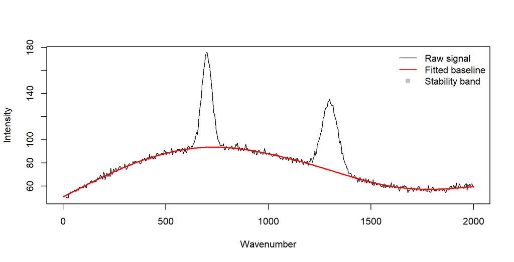

```r
plot(boot)
```

## 4.3 Core API

| Function | Purpose |
| --- | --- |
| `gcv_select_lambda()` | Search a $\lambda$ grid, return the best fit |
| `bootstrap_baseline_uncertainty()` | Add a bootstrap stability band (`B = 200` by default) |
| `fit_arpls()` | ARPLS at a fixed $\lambda$ |
| `print()` `summary()` `plot()` | Inspect a result |
| `predict()` | Baseline on a new wavenumber grid |
| `compare()` | Compare two fits |

```r
predict(boot, newdata = c(250, 750, 1250, 1750))
```

```
## [1] 72.70566 93.67478 76.52855 57.29391
```

# 5 Benchmark and validation

## 5.1 Benchmark: compiled vs pure-R engine

```r
bench_lambda <- 1e5; n_inner <- 200
time_engine <- function(engine) {
  as.numeric(system.time(
    for (i in seq_len(n_inner)) engine(raw_signal, bench_lambda, 0.05, 50L, 1e-6)
  )["elapsed"]) / n_inner
}
t_cpp <- time_engine(StatARPLS:::arpls_engine)
t_r   <- time_engine(StatARPLS:::arpls_engine_r)
knitr::kable(data.frame(engine = c("Rcpp (compiled)", "Pure R reference"),
                        seconds_per_fit = signif(c(t_cpp, t_r), 3),
                        speedup = c(signif(t_r / t_cpp, 3), 1)))
```

| engine | seconds_per_fit | speedup |
| --- | --- | --- |
| Rcpp (compiled) | 0.0054 | 18.9 |
| Pure R reference | 0.1020 | 1.0 |

- Same algorithm, same results (the R engine is the correctness check). Timed on a 500-point spectrum.
- This compares against **my own** pure-R reference, not against other packages.

## 5.2 Scaling (dense solver)

Measured on my laptop, one spectrum:

| Spectrum length $n$ | Operation | Time |
| --- | --- | --- |
| 1,868 (FTIR) | GCV over 13 $\lambda$ values | about 1.7 s |
| 1,868 (FTIR) | Bootstrap, $B = 100$ | about 16 s |
| 3,092 (Raman) | GCV over 13 $\lambda$ values | about 9.8 s |

- Cost grows steeply with $n$ because the linear solve is **dense**.
- A banded / sparse solve would remove this; it is **future work**, not claimed here.

## 5.3 Comparison with `baseline` methods

**Simulation with a known baseline** (20 spectra, 1,868 points; smooth curved baseline, 8 narrow peaks, noise SD 0.01). Error = RMSE of the estimated baseline against the true one.

| Method | Median RMSE |
| --- | --- |
| **StatARPLS (automatic $\lambda$)** | **0.0042** |
| AsLS, $\lambda = 10^7$ | 0.0168 |
| AsLS, $\lambda = 10^5$ | 0.0288 |
| Polynomial fit (degree 4) | 0.0625 |
| IRLS (default) | 0.0744 |
| AsLS, $\lambda = 10^3$ | 0.1065 |

- StatARPLS had the lowest error on **20 of 20** simulated spectra: about **4 times lower** than the best of three hand-picked AsLS settings.
- **AsLS depends on the guess**: on the 16 real FTIR spectra its baseline moved by a median of **30% of the signal range** between $\lambda = 10^3$ and $10^7$.
- On those 16 spectra StatARPLS chose different $\lambda$ for different spectra ($3\times10^5$ to $10^8$).

**What this does and does not show**

- AsLS was **not tuned**: three fixed guesses, not its best $\lambda$. Tuned AsLS may be closer.
- The simulation has narrow peaks and a smooth baseline, where GCV works well. It does not include broad peaks.
- Speed: `baseline` AsLS is **faster per fit** (sparse solver, under 1 ms against about 1.7 s here, where StatARPLS also searches 13 $\lambda$ values). I do not claim to be faster than `baseline`.

## 5.4 Real data: FTIR (ChemoSpec `SrE.IR`)

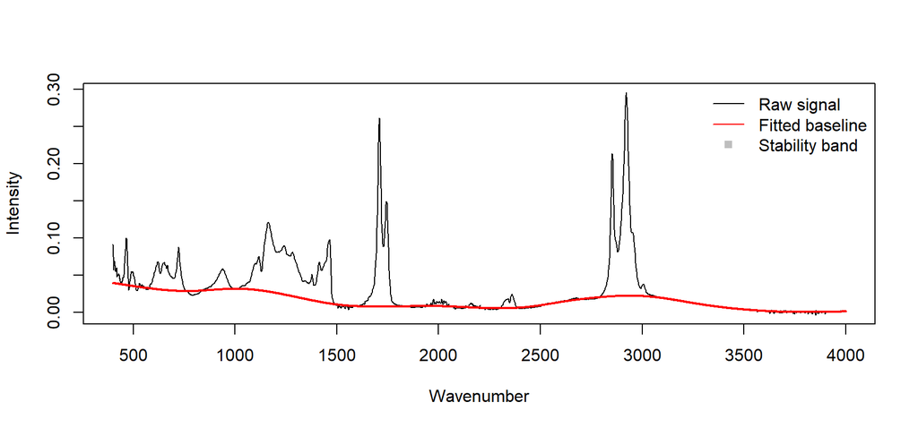

```r
data("SrE.IR", package = "ChemoSpec")
ord <- order(SrE.IR$freq)                       # axis must be increasing
wn  <- SrE.IR$freq[ord]; y <- SrE.IR$data[1, ord]
fit_ir  <- gcv_select_lambda(y, wn, seed = 1)
boot_ir <- bootstrap_baseline_uncertainty(fit_ir, B = 50, seed = 2)
plot(boot_ir)
```

- 16 spectra (14 saw palmetto extracts and 2 reference oils), 1,868 points each.[3] The band is thin because the noise is small.

## 5.5 Real data: textile ATR-FTIR (Mendeley, CC BY 4.0)

160 spectra, 4000-550 cm<sup>-1</sup>; 4 fibres shown (first spectrum of each type). Data: Parkar et al. [2], public, CC BY 4.0. Changes: transmission converted to absorbance; every 2nd point kept.

| Fibre | Default grid | Larger minimum $\lambda$ | df | Band width |
| --- | --- | --- | --- | --- |
| Protein (alpaca) | $\lambda = 100$, follows peaks | $3.2\times10^{8}$ | 4.0 | 0.0018 |
| Cellulose (cotton) | $3.2\times10^{7}$, good | same | 6.1 | 0.0009 |
| Polyester (PET) | $\lambda = 100$, follows peaks | $3.2\times10^{6}$ | 14.7 | 0.0037 |
| Acrylic (PAN/MA) | $1\times10^{6}$, broad bumps | same | 18.0 | 0.0004 |

- The new warning fired on **exactly** the two failed fits.

Fits with the larger minimum $\lambda$ (baseline under the peaks in all four):

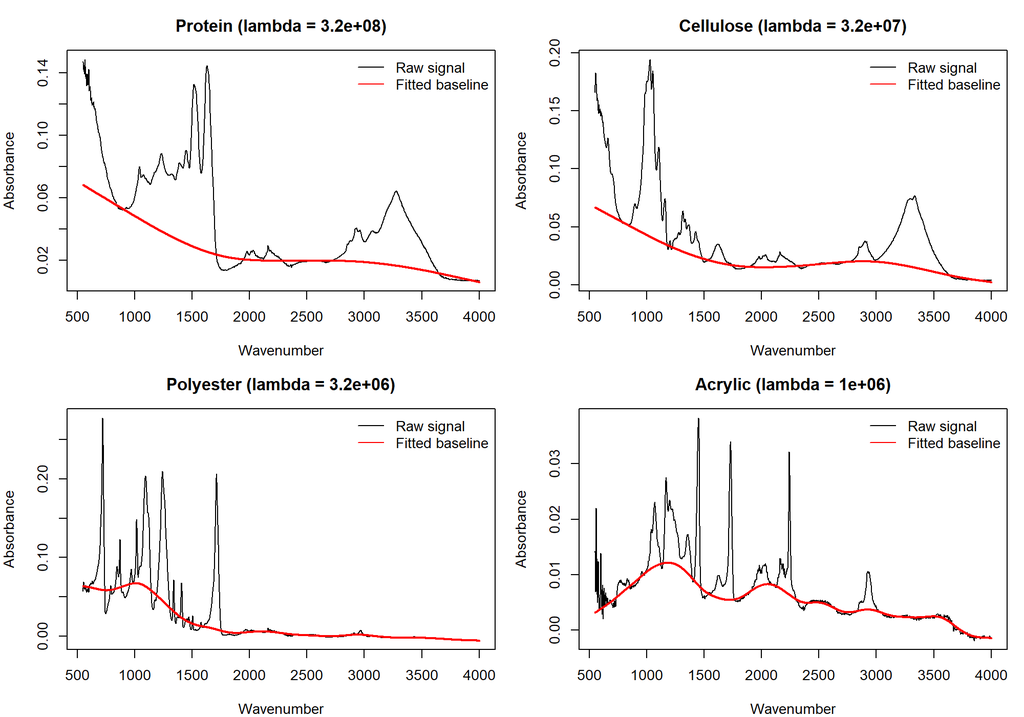

Bootstrap stability bands on the same fits. The bands are only 0.0004 to 0.004 wide (see the table), so they are too thin to see at this scale. Acrylic’s band is thinnest, but its baseline still follows broad bumps: **a thin band does not mean a correct baseline**.

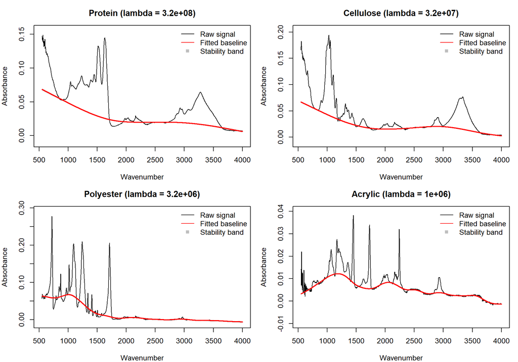

## 5.6 Honest findings and limits

- GCV can select a lambda that is too small for some reweighted fits, producing an overly flexible baseline. StatARPLS warns the user, and a larger minimum lambda (grid) can be supplied to reduce this risk. The fitted baseline should still be checked.
- **The band is sampling stability, not total error.** A thin band does not mean the baseline is right (Acrylic is thin but follows broad bumps).
- **Broad peaks can be absorbed** into the baseline, a known ARPLS weakness.
- **Dense solver**: slow beyond a few thousand points.
- Bootstrap pool excludes peak points, so block dependence is approximate across gaps.

# 6 Quality and summary

## 6.1 Quality assurance

- **98 passing `testthat` tests** (as counted by `devtools::test()`), no failures.
- **`R CMD check`**: 0 errors, 0 warnings, 0 notes.
- Full roxygen documentation, an introduction **vignette**, and S3 methods registered in `NAMESPACE`.
- Source on GitHub: `github.com/tardagur/StatARPLS` (open source).

## 6.2 Summary

- **Problem**: ARPLS needs hand-tuned $\lambda$ and gives no uncertainty.
- **`StatARPLS`**: automatic $\lambda$ (GCV) + bootstrap stability band + compiled solver, in one tested S3 package.

**Evidence**:

- The compiled solver was over 10 times faster than the pure-R reference implementation in the benchmark.
- In the known-baseline simulation, StatARPLS had approximately four times lower baseline RMSE than the particular untuned AsLS setting tested.
- Testing on textile spectra revealed a failure mode in 2 of the 4 spectra examined; the warning helps flag this issue.
- Performance and accuracy depend on the dataset and comparison settings.
- **Next**: sparse solver (to close the speed gap with `baseline`), comparison against AsLS at its best $\lambda$, a better selection rule than plain GCV.

**Questions?**

## References

[1] K. H. Liland, T. Almøy, and B.-H. Mevik, “Optimal choice of baseline correction for multivariate calibration of spectra,” *Applied Spectroscopy*, vol. 64, no. 9, pp. 1007–1016, 2010, doi: 10.1366/000370210792434350.

[2] R. Parkar, A. Jain, M. Prendergast-Miller, T. Stanton, K. Sheridan, and M. Gallidabino, “A dataset of infrared (ATR-FTIR) spectra for textile fibres of natural and man-made origin,” Mendeley Data, ver. 3, Feb. 2026, doi: 10.17632/rx3fjgz96x.3. Licence: CC BY 4.0.

[3] B. A. Hanson, “ChemoSpec: Exploratory chemometrics for spectroscopy,” R package version 6.3.1, 2025. [Online]. Available: https://CRAN.R-project.org/package=ChemoSpec